# Reasoning

Reasoning is quintessential for intelligent agents, in this blog post we'll review primary categories of reasoning (Inductive, deductive, and abductive reasoning). Secondly, we'll look into various taxonomies (Formal reasoning vs Informal reasoning, Neural reasoning vs Symbolic reasoning vs Neural symbolic reasoning, Backward reasoning vs Forward reasoning, Single step reasoning vs Multi-step reasoning, Deductive reasoning vs Defeasible reasoning, Unimodal reasoning vs Multimodal reasoning), Lastly, we'll review various reasoning tasks (Commonsense reasoning, Mathematical reasoning, Logical reasoning, Causal reasoning, Visual reasoning, Multimodal reasoning, Embodied reasoning, Other reasoning tasks) [1,2]

## I. Introduction

- Abductive reasoning represents the process of making plausible explanations or hypotheses to account for observed facts or data. It involves inferring the best possible explanations from incomplete or limited information. It is used in problem-solving and hypothesis generation.
- Deductive reasoning is a logical process that derives specific conclusions from general premises or principles. It leverages a top-down approach starting from general principles and applying logical rules to reach a specific conclusion. Its main goal is to provide logically valid and conclusive results.
- Inductive reasoning is about providing general conclusions or patterns based on specific observations or evidence.

Other taxonomies of reasoning :

- Formal reasoning vs Informal reasoning: Formal reasoning involves following strict rules, logical frameworks, or formal systems to derive conclusions and often relies on Mathematical or deductive reasoning. On the other hand, Informal reasoning is less structured and more intuitive relying on personal experience, commonsense, and heuristics
- Neural reasoning vs Symbolic reasoning vs Neural-Symbolic reasoning: Neural reasoning is about using artificial neural networks for reasoning tasks. Symbolic reasoning involves using symbolic representations logic-based inference rules or symbolic manipulation for reasoning. Neural-symbolic reasoning combines the elements of both Neural reasoning and Symbolic reasoning
- Backward reasoning vs Forward reasoning: Backward reasoning starts from a goal and works backward by applying rules or evidence to determine the necessary conditions or steps to reach that goal Whereas Forward reasoning starts with initial evidence and progresses step-by-step to derive new conclusions or reach an outcome
- Single-step reasoning vs Multi-step reasoning: Multi-step reasoning refers to tasks that require multiple sequential or interconnected steps to arrive at a solution or a conclusion. Single-step uses a single step to reach a solution
- Deductive reasoning vs Defeasible reasoning: Defeasible reasoning involves reasoning under uncertainty or with incomplete information where a conclusion can be overridden or defeated by new evidence or exceptions.
- Unimodal reasoning vs Multimodal reasoning: Unimodal reasoning refers to reasoning tasks that involve a single modality of information or input. On the other hand, Multimodal reasoning involves integrating and reasoning with multiple modalities of information simultaneously (Texts, images, and audio data)

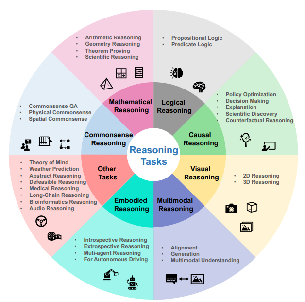

Taxomy of various reasoning tasks [1]

## II. Tasks

### II.1 Commonsense Reasoning

Commonsense reasoning refers to the human-like capacity to make assumptions and inferences about the nature and characteristics of everyday situations that humans encounter daily

- Commonsense question and answering is about devising systems capable of answering questions that require a deep understanding of everyday knowledge and human-like reasoning
- Physical Commonsense reasoning involves utilizing everyday knowledge about the physical world to reason and understand the behavior of objects and their properties
- Spatial Commonsense reasoning involves detecting the spatial position of objects and inferring the relationships between visual stimuli to understand the surrounding environment

### II.2 Mathematical Reasoning

It contains the following categories:

- Arithmetic reasoning
- Geometry reasoning
- Automated theorem proving
- Scientific reasoning

### II.3 Logical Reasoning

Logical reasoning is a rigorous form of thinking that involves using premises and their relations to derive conclusions that are implied by the premises.

- Propositional Logic deals with declarative sentences that can be assigned a truth value, either true or false, without any ambiguity
- Predicate Logic is an extension of propositional logic allowing for more nuanced expressions

### II.4 Causal Reasoning

Causal reasoning is the process of understanding and explaining the cause-and-effect relationship between events, actions, or variables. It has the following categories :

- Policy Optimization
- Decision making
- Explanation
- Scientific Discovery
- Counterfactual reasoning

### II.5 Visual Reasoning

Visual reasoning refers to the cognitive process of understanding, analyzing, and drawing conclusions from visual information

- 2D Reasoning is about understanding, analyzing, and reasoning about 2D objects
- 3D Reasoning refers to the cognitive process of understanding, analyzing, and reasoning about 3D objects or spatial arrangements

### II.6 Multimodal Reasoning

Multimodal reasoning is a cognitive process of integrating and reasoning across multiple modalities of information such as text, images, videos, and other sensory inputs, to enhance understanding and perform complex reasoning tasks, It can be categorized into :

- Alignment methods
- Generation methods
- Multimodal Understanding methods

### II.7 Embodied Reasoning

Embodied reasoning is about agent reasoning, and is an important capability for Autonomous Language Agents, which refers to a cognitive process that integrates perception, action, and interaction with the physical environment or simulated environment to support reasoning and problem-solving. It contains the following categories :

- Introspective reasoning
- Extrospective reasoning
- Multi-agent reasoning
- For Autonomous Driving

### II.8 Others Tasks

Other applications and tasks can be categorized into :

- Theory of mind
- Weather prediction
- Abstract reasoning
- Medical reasoning
- Long-chain reasoning
- Bioinformatics reasoning
- Audio reasoning

## III. References

1. Jiankai Sun and Chuanyang Zheng and Enze Xie and Zhengying Liu and Ruihang Chu and Jianing Qiu and Jiaqi Xu and Mingyu Ding and Hongyang Li and Mengzhe Geng and Yue Wu and Wenhai Wang and Junsong Chen and Zhangyue Yin and Xiaozhe Ren and Jie Fu and Junxian He and Wu Yuan and Qi Liu and Xihui Liu and Yu Li and Hao Dong and Yu Cheng and Ming Zhang and Pheng Ann Heng and Jifeng Dai and Ping Luo and Jingdong Wang and Ji-Rong Wen and Xipeng Qiu and Yike Guo and Hui Xiong and Qun Liu and Zhenguo Li. A Survey of Reasoning with Foundation Models. Arxiv, 2024
2. Fei Yu and Hongbo Zhang and Prayag Tiwari and Benyou Wang. Natural Language Reasoning, A Survey. Arxiv, 2023.